# Wine Quality Prediction

Amine Agrane & Lydia Khelfane

10/02/2021

# Dataset and variables Presentation

In this notebook we will use the data from the Kaggle Repository (https://www.kaggle.com/rajyellow46/wine-quality) by P. Cortez, A. Cerdeira, F. Almeida, T. Matos, and J. Reis. The data include examples of red and white wines from Portugal-one of the world’s leading wine-producing countries.

For each wine, a laboratory analysis measured characteristics such as acidity, sugar content, chlorides, sulfur, alcohol, pH, and density. The samples were then rated in a blind tasting by panels of no less than three judges on a quality scale ranging from zero (very bad) to 10 (excellent). In the case of judges disagreeing on the rating, the median value was used.

The wine dataset is composed by a total of 14 different variables :

**1- fixed acidity (tartaric acid - g/dm3)** : most acids involved with wine or fixed or nonvolatile (do not evaporate readily)

**2- volatile acidity (acetic acid - g/dm3)**: the amount of acetic acid in wine, which at too high of levels can lead to an unpleasant, vinegar taste

**3- citric acid (g/dm3)** : found in small quantities, citric acid can add ‘freshness’ and flavor to wines

**4- residual sugar (g/dm3)** : the amount of sugar remaining after fermentation stops, it’s rare to find wines with less than 1 gram/liter and wines with greater than 45 grams/liter are considered sweet

**5- chlorides (sodium chloride - g/dm3)** : the amount of salt in the wine

**6- free sulfur dioxide (mg/dm3)** : the free form of SO2 exists in equilibrium between molecular SO2 (as a dissolved gas) and bisulfite ion; it prevents microbial growth and the oxidation of wine

**7- total sulfur dioxide (mg/dm3)** : amount of free and bound forms of S02; in low concentrations, SO2 is mostly undetectable in wine, but at free SO2 concentrations over 50 ppm, SO2 becomes evident in the nose and taste of wine

**8- density (g/cm3)** : the density of water is close to that of water depending on the percent alcohol and sugar content

**9- pH** : describes how acidic or basic a wine is on a scale from 0 (very acidic) to 14 (very basic); most wines are between 3-4 on the pH scale

**10- sulphates (potassium sulphate - g/dm3)** : a wine additive which can contribute to sulfur dioxide gas (S02) levels, wich acts as an antimicrobial and antioxidant

**11- alcohol (% by volume)** : the percent alcohol content of the wine Output variable (based on sensory data):

**12- quality**: score between 0 and 10 that describes the quality of the wine.

**14- color**: color of the wine. There are two type wine, red wine and white wine.

## Exploratory Data Analysis on the wine dataset

##### Load the wine dataset

We start by reading the data which is stored in the csv file `winequality.csv`. The file is loaded using the `read.csv` command, along with the `as.data.frame` command which store our data inside a structure of dataframe type.

```r
# Load the data
df_wine <- as.data.frame( read.csv(file = './data/winequality.csv', sep=',', stringsAsFactors=F))
head(df_wine)
```

|  | fixed.acidity | volatile.acidity | citric.acid | residual.sugar | chlorides | free.sulfur.dioxide | total.sulfur.dioxide | density | pH | sulphates | alcohol | quality | good | color |
| --- | --- | --- | --- | --- | --- | --- | --- | --- | --- | --- | --- | --- | --- | --- |
| 1 | 7.4 | 0.70 | 0.00 | 1.9 | 0.076 | 11 | 34 | 0.9978 | 3.51 | 0.56 | 9.4 | 5 | 0 | red |
| 2 | 7.8 | 0.88 | 0.00 | 2.6 | 0.098 | 25 | 67 | 0.9968 | 3.20 | 0.68 | 9.8 | 5 | 0 | red |
| 3 | 7.8 | 0.76 | 0.04 | 2.3 | 0.092 | 15 | 54 | 0.9970 | 3.26 | 0.65 | 9.8 | 5 | 0 | red |
| 4 | 11.2 | 0.28 | 0.56 | 1.9 | 0.075 | 17 | 60 | 0.9980 | 3.16 | 0.58 | 9.8 | 6 | 0 | red |
| 5 | 7.4 | 0.70 | 0.00 | 1.9 | 0.076 | 11 | 34 | 0.9978 | 3.51 | 0.56 | 9.4 | 5 | 0 | red |
| 6 | 7.4 | 0.66 | 0.00 | 1.8 | 0.075 | 13 | 40 | 0.9978 | 3.51 | 0.56 | 9.4 | 5 | 0 | red |

```r
tail(df_wine)
```

|  | fixed.acidity | volatile.acidity | citric.acid | residual.sugar | chlorides | free.sulfur.dioxide | total.sulfur.dioxide | density | pH | sulphates | alcohol | quality | good | color |
| --- | --- | --- | --- | --- | --- | --- | --- | --- | --- | --- | --- | --- | --- | --- |
| 6492 | 6.5 | 0.23 | 0.38 | 1.3 | 0.032 | 29 | 112 | 0.99298 | 3.29 | 0.54 | 9.7 | 5 | 0 | white |
| 6493 | 6.2 | 0.21 | 0.29 | 1.6 | 0.039 | 24 | 92 | 0.99114 | 3.27 | 0.50 | 11.2 | 6 | 0 | white |
| 6494 | 6.6 | 0.32 | 0.36 | 8.0 | 0.047 | 57 | 168 | 0.99490 | 3.15 | 0.46 | 9.6 | 5 | 0 | white |
| 6495 | 6.5 | 0.24 | 0.19 | 1.2 | 0.041 | 30 | 111 | 0.99254 | 2.99 | 0.46 | 9.4 | 6 | 0 | white |
| 6496 | 5.5 | 0.29 | 0.30 | 1.1 | 0.022 | 20 | 110 | 0.98869 | 3.34 | 0.38 | 12.8 | 7 | 1 | white |
| 6497 | 6.0 | 0.21 | 0.38 | 0.8 | 0.020 | 22 | 98 | 0.98941 | 3.26 | 0.32 | 11.8 | 6 | 0 | white |

#### Basic analysis on the dataset

Now we’re gonna achieve some basic analysis on our wine dataset to get a better understanding of its contents, size and structure.

**Dimension of our wine Dataset :**

```r
cat('The number of rows inside the dataset is : ', dim(df_wine)[1])
```

```
The number of rows inside the dataset is :  6497
```

```r
cat('The number of columns/features inside the dataset is : ', dim(df_wine)[2])
```

```
The number of columns/features inside the dataset is :  14
```

**Structure and distribution of the variables :**

We use the `str` and `summary` functions to display some basic statistics about our dataset. The `str` function shows the nature (type) of each variable (feature) of our dateset, and some values that the feature can take. The `summary` function in other hand give us some statistics metrics (min, max, median, etc) for each feature of the dataset.

```r
str(df_wine)
summary(df_wine)
```

[output not shown]

**Correlation between the variables :**

```r
as.data.frame( cor(df_wine[c(-13, -14)]))
```

|  | fixed.acidity | volatile.acidity | citric.acid | residual.sugar | chlorides | free.sulfur.dioxide | total.sulfur.dioxide | density | pH | sulphates | alcohol | quality |
| --- | --- | --- | --- | --- | --- | --- | --- | --- | --- | --- | --- | --- |
| fixed.acidity | 1.00000000 | 0.21900826 | 0.32443573 | -0.11198128 | 0.29819477 | -0.28273543 | -0.32905390 | 0.45890998 | -0.25270047 | 0.299567744 | -0.095451523 | -0.07674321 |
| volatile.acidity | 0.21900826 | 1.00000000 | -0.37798132 | -0.19601117 | 0.37712428 | -0.35255731 | -0.41447619 | 0.27129565 | 0.26145440 | 0.225983680 | -0.037640386 | -0.26569948 |
| citric.acid | 0.32443573 | -0.37798132 | 1.00000000 | 0.14245123 | 0.03899801 | 0.13312581 | 0.19524198 | 0.09615393 | -0.32980819 | 0.056197300 | -0.010493492 | 0.08553172 |
| residual.sugar | -0.11198128 | -0.19601117 | 0.14245123 | 1.00000000 | -0.12894050 | 0.40287064 | 0.49548159 | 0.55251695 | -0.26731984 | -0.185927405 | -0.359414771 | -0.03698048 |
| chlorides | 0.29819477 | 0.37712428 | 0.03899801 | -0.12894050 | 1.00000000 | -0.19504479 | -0.27963045 | 0.36261466 | 0.04470798 | 0.395593307 | -0.256915580 | -0.20066550 |
| free.sulfur.dioxide | -0.28273543 | -0.35255731 | 0.13312581 | 0.40287064 | -0.19504479 | 1.00000000 | 0.72093408 | 0.02571684 | -0.14585390 | -0.188457249 | -0.179838435 | 0.05546306 |
| total.sulfur.dioxide | -0.32905390 | -0.41447619 | 0.19524198 | 0.49548159 | -0.27963045 | 0.72093408 | 1.00000000 | 0.03239451 | -0.23841310 | -0.275726820 | -0.265739639 | -0.04138545 |
| density | 0.45890998 | 0.27129565 | 0.09615393 | 0.55251695 | 0.36261466 | 0.02571684 | 0.03239451 | 1.00000000 | 0.01168608 | 0.259478495 | -0.686745422 | -0.30585791 |
| pH | -0.25270047 | 0.26145440 | -0.32980819 | -0.26731984 | 0.04470798 | -0.14585390 | -0.23841310 | 0.01168608 | 1.00000000 | 0.192123407 | 0.121248467 | 0.01950570 |
| sulphates | 0.29956774 | 0.22598368 | 0.05619730 | -0.18592741 | 0.39559331 | -0.18845725 | -0.27572682 | 0.25947850 | 0.19212341 | 1.000000000 | -0.003029195 | 0.03848545 |

[output cut: 2 more lines]

**Number of NAN values for each variables :**

```r
cat('Number of NAN values for each variable :', colSums(is.na(df_wine)))
```

```
Number of NAN values for each variable : 0 0 0 0 0 0 0 0 0 0 0 0 0 0
```

# Preparing the data

We want to predict the quality of the wine (score between 1 and 10) by using the rest of the feature variables. Here, wine quality is the variable we want to predict (Y variable).

First let’s take a look at the distribution of the wine quality score in our dataset. We see that Wine quality appear to follow a bell shaped distribution (Gaussian/Normal distribution). This implies most wines are of average quality and few are good or bad

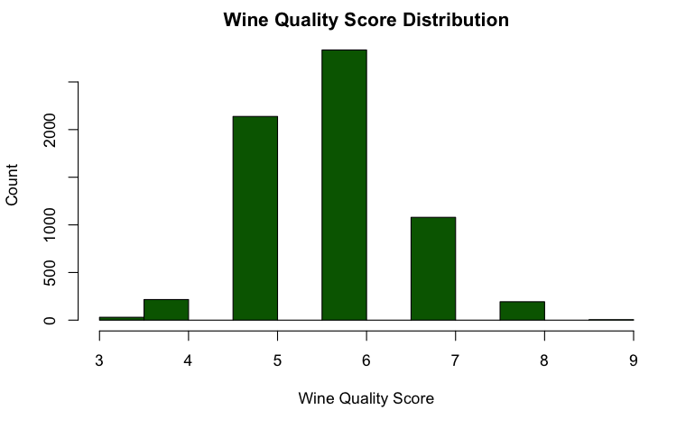

```r
# Simple Bar Plot
hist(df_wine$quality, main="Wine Quality Score Distribution",ylab="Count", xlab="Wine Quality Score", breaks=10, , col= "darkgreen")
```

Now let’s check the frequency of each wine quality score. From the above table, we see that an approximate 45% of the wine quality scoes have a 6 score value.

```r
table(df_wine$quality)
```

```
   3    4    5    6    7    8    9
  30  216 2138 2836 1079  193    5
```

## Binning the Quality Score Variable

We turn our Y variable into a two class variable. We will have the class “bad” for the lower wines (in terms of quality) and the class “good” for the best wines. We have to set a treshold on the wine quality score to assert if it’s a good or bad wine.

Scond threshold : - High : scores from 6 to 9. - Low : scores from 1 to 5.

```r
cat('First threshold class distribution : ', table(ifelse(df_wine$quality<=6,'Bad', ifelse(df_wine$quality>=7, "Good","")) ))
```

```
First threshold class distribution :  5220 1277
```

```r
cat('Second threshold class distribution : ', table(ifelse(df_wine$quality<=5,'Bad', ifelse(df_wine$quality>=6, "Good",""))))
```

```
Second threshold class distribution :  2384 4113
```

```r
qualityFactor <-ifelse(df_wine$quality<=4,'low',
            ifelse(df_wine$quality>=5 & df_wine$quality<=7, "average",
            ifelse(df_wine$quality>7,"high", "")))
wineData <- data.frame(df_wine, qualityFactor)
```

```r
ggplot(df_wine, aes(x =fct_reorder(qualityFactor, alcohol) , y = alcohol, fill=qualityFactor))+ geom_boxplot()
ggplot(df_wine, aes(x =fct_reorder(qualityFactor, density) , y = density, fill=qualityFactor))+ geom_boxplot()
```

[output not shown]

## Data Preparation

```r
#training set
wine_train <- wine[1:3750, ]

#test set
wine_test <- wine[3751:4898, ]
```